# Análisis Exploratorio del Mercado de Criptomonedas

Rafael Romero, Mateo Barrios

2026-02-23

```r
library(httr)
library(jsonlite)
library(dplyr)
library(ggplot2)
library(scales)
library(knitr)

options(scipen = 999)
theme_set(theme_minimal())
```

# 1. Introducción

Este informe presenta un análisis exploratorio del mercado de criptomonedas utilizando datos obtenidos desde la API de CryptoCompare.

Se analizan variables numéricas clave:

- Precio (USD)
- Capitalización de mercado
- Volumen 24 horas
- Cambio porcentual 24 horas

El objetivo es comprender la estructura del mercado, su dispersión y nivel de concentración.

# 2. Obtención de Datos

```r
datos <- data.frame()

for (i in 0:9) {
  url <- paste0("https://min-api.cryptocompare.com/data/top/mktcapfull?limit=100&tsym=USD&page=", i)
  resp <- tryCatch(GET(url), error = function(e) NULL)

  if (!is.null(resp) && status_code(resp) == 200) {
    json <- fromJSON(content(resp, "text", encoding = "UTF-8"))
    if (!is.null(json$Data)) {
      temp <- data.frame(
        nombre = json$Data$CoinInfo$FullName,
        simbolo = json$Data$CoinInfo$Name,
        precio = json$Data$RAW$USD$PRICE,
        mcap = json$Data$RAW$USD$MKTCAP,
        volumen = json$Data$RAW$USD$TOTALVOLUME24H,
        cambio = json$Data$RAW$USD$CHANGEPCT24HOUR,
        stringsAsFactors = FALSE
      )
      datos <- bind_rows(datos, temp)
    }
  }
  Sys.sleep(0.5)
}

datos <- na.omit(datos)
nrow(datos)
```

```
## [1] 740
```

El número anterior corresponde a la cantidad total de criptomonedas analizadas.

# 3. Estadística Descriptiva

```r
data.frame(
  Variable = c("Precio", "Market Cap", "Volumen 24h", "Cambio % 24h"),
  Media = c(mean(datos$precio),
            mean(datos$mcap),
            mean(datos$volumen),
            mean(datos$cambio)),
  Mediana = c(median(datos$precio),
              median(datos$mcap),
              median(datos$volumen),
              median(datos$cambio)),
  Desv_Estandar = c(sd(datos$precio),
                    sd(datos$mcap),
                    sd(datos$volumen),
                    sd(datos$cambio)),
  Coef_Variacion = c(sd(datos$precio)/mean(datos$precio),
                     sd(datos$mcap)/mean(datos$mcap),
                     sd(datos$volumen)/mean(datos$volumen),
                     sd(datos$cambio)/mean(datos$cambio))
)
```

```
##       Variable                 Media           Mediana          Desv_Estandar
## 1       Precio            306.939866        0.05892988            4138.177011
## 2   Market Cap     3350546809.506112 57318642.99709307     49374265485.960983
## 3  Volumen 24h 22288752182199.289062 63797654.18148015 573915949607422.875000
## 4 Cambio % 24h             -2.317539       -2.28028819               4.844853
##   Coef_Variacion
## 1      13.482045
## 2      14.736181
## 3      25.749129
## 4      -2.090516
```

Interpretación:

El coeficiente de variación permite comparar dispersión relativa entre variables. Valores altos indican alta heterogeneidad en el mercado.

# 4. Percentiles y Cuartiles

```r
quantile(datos$precio, probs = seq(0,1,0.25))
```

```
##                 0%                25%                50%                75%
##     0.000000000371     0.010421044194     0.058929880190     0.339176158233
##               100%
## 64954.284044737702
```

```r
quantile(datos$mcap, probs = seq(0,1,0.25))
```

```
##               0%              25%              50%              75%
##         95095.93      22125500.00      57318643.00     200698184.17
##             100%
## 1298686601773.58
```

Esto permite observar cómo se distribuyen los datos por tramos.

# 5. Distribuciones

## Precio

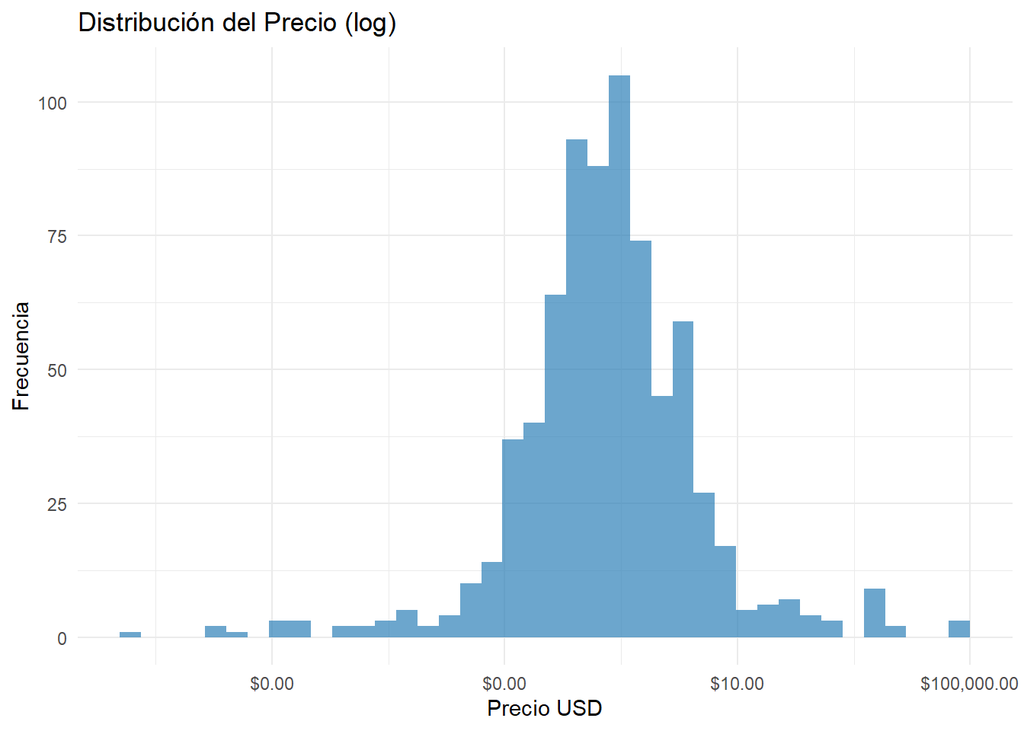

```r
ggplot(datos, aes(x = precio)) +
  geom_histogram(bins = 40, fill = "#2c7fb8", alpha = 0.7) +
  scale_x_log10(labels = dollar_format()) +
  labs(title = "Distribución del Precio (log)",
       x = "Precio USD",
       y = "Frecuencia")
```

La distribución muestra fuerte asimetría positiva.

## Market Cap

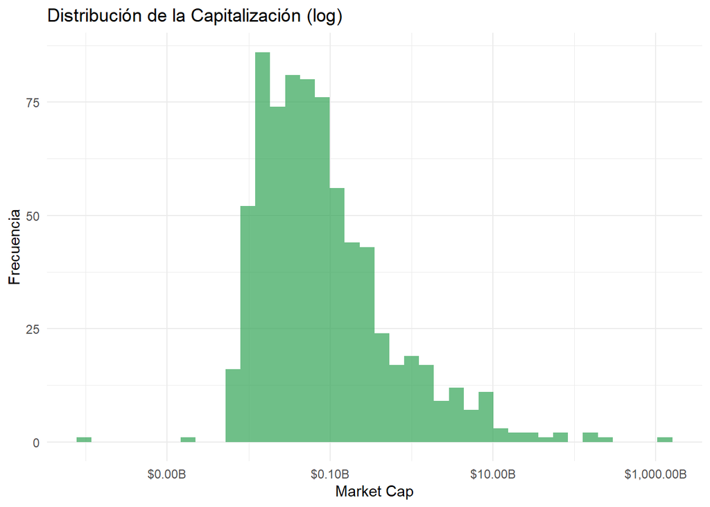

```r
ggplot(datos, aes(x = mcap)) +
  geom_histogram(bins = 40, fill = "#31a354", alpha = 0.7) +
  scale_x_log10(labels = dollar_format(scale = 1e-9, suffix = "B")) +
  labs(title = "Distribución de la Capitalización (log)",
       x = "Market Cap",
       y = "Frecuencia")
```

Se observa concentración en pocas criptomonedas de gran tamaño.

# 6. Detección de Outliers (Método IQR)

```r
Q1 <- quantile(datos$precio, 0.25)
Q3 <- quantile(datos$precio, 0.75)
IQR_precio <- Q3 - Q1

limite_superior <- Q3 + 1.5 * IQR_precio
sum(datos$precio > limite_superior)
```

```
## [1] 139
```

Esto identifica valores extremos según criterio estadístico estándar.

# 7. Relación entre Variables

```r
cor(datos[,c("precio","mcap","volumen","cambio")], use="complete.obs")
```

```
##               precio         mcap      volumen      cambio
## precio   1.000000000  0.560995336 -0.002884490 0.001507104
## mcap     0.560995336  1.000000000 -0.002573818 0.001957577
## volumen -0.002884490 -0.002573818  1.000000000 0.003072627
## cambio   0.001507104  0.001957577  0.003072627 1.000000000
```

# 8. Índice de Concentración (HHI)

```r
participaciones <- datos$mcap / sum(datos$mcap)
HHI <- sum(participaciones^2)
HHI
```

```
## [1] 0.2944076
```

El índice Herfindahl-Hirschman mide concentración de mercado.

Valores más altos indican mayor concentración.

# 9. Curva de Concentración

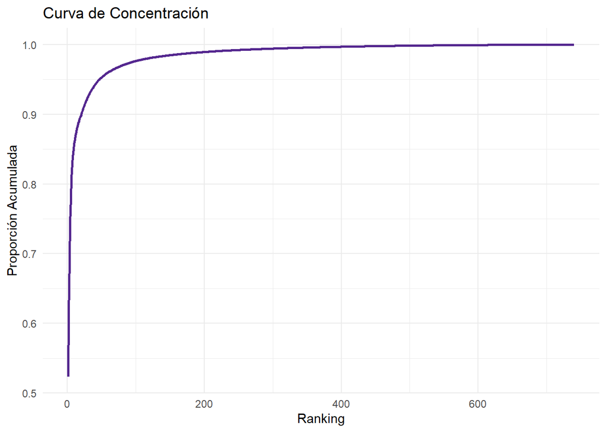

```r
datos_ordenados <- datos %>%
  arrange(desc(mcap)) %>%
  mutate(
    ranking = row_number(),
    acumulado = cumsum(mcap)/sum(mcap)
  )

ggplot(datos_ordenados, aes(x=ranking, y=acumulado)) +
  geom_line(color="#54278f", size=1) +
  labs(title="Curva de Concentración",
       x="Ranking",
       y="Proporción Acumulada")
```

# 10. Conclusiones

1. El mercado presenta fuerte asimetría y alta dispersión.
2. El coeficiente de variación indica gran heterogeneidad.
3. Existen valores extremos significativos.
4. El índice HHI confirma concentración elevada.
5. Pocas criptomonedas dominan el mercado global.
6. Precio y capitalización presentan relación positiva clara.